# Visualizing Hedge Fund Industry Performance in 2015

April 23, 2016

## Outline

- Background
- Fund Performance by Sector
- Total Fund Performance
- Conclusion & Future Analysis

## Background

## Why Do We Care?

[figure not shown]

## Dataset

- Universe: Returns of Long Only Portfolio for 850+ funds based on Public SEC Regulatory Quarterly Filings (13F & D filings) in 2015
- Sectors: Consumer Discretionary, Consumer Staples, Energy, Financials, Health Care, Industrials, Information Technology, Materials

## Fund Performance by Sector

## Sector Overview

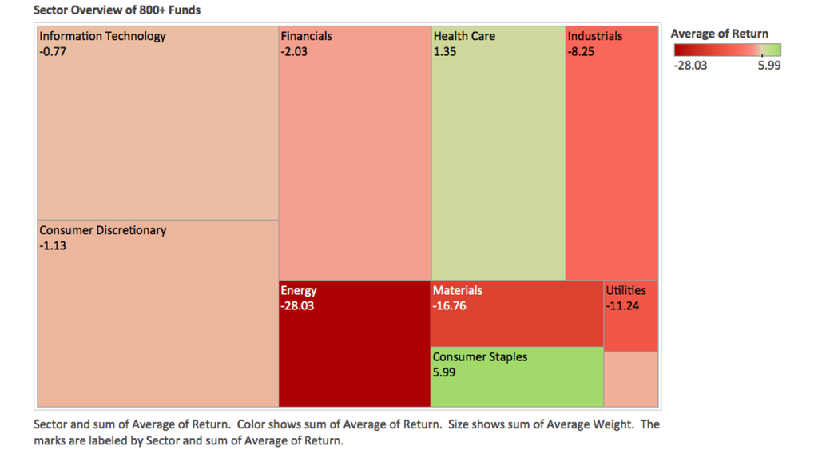

## Fund Performance Overview

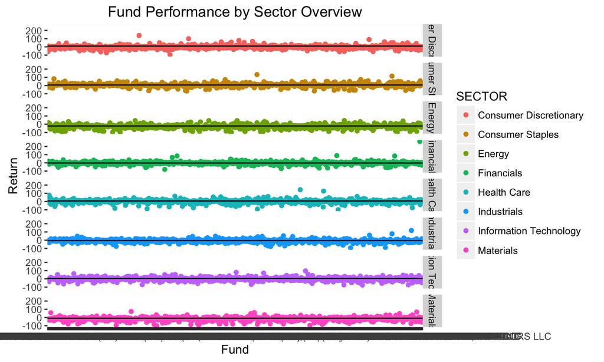

## Fund Performance Distribution by Sector

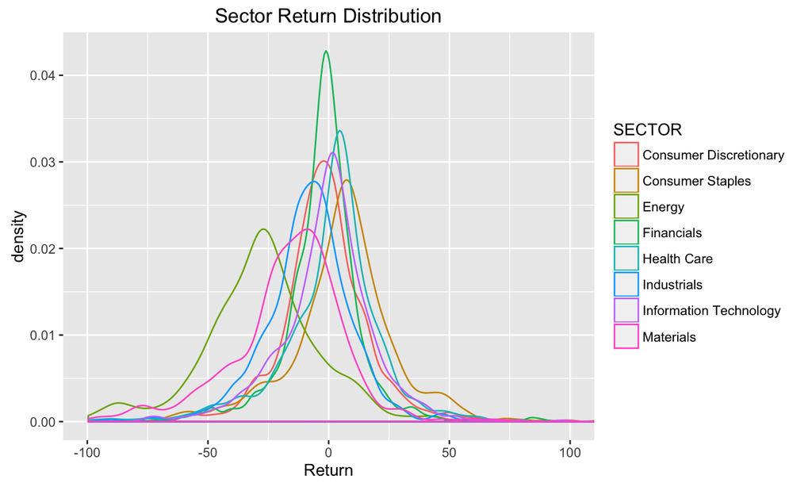

## What Were the Top Ten Performing Funds in Each Sector?

- Top performing fund selection criteria:
  - Sharpe ratio > 0
  - Number of positions > 10
  - Average weight > 10%
  - % Win > 50%
  - Return > Sector Benchmark Return

## What Were the Top Ten Performing Funds in Each Sector?

- Sector Benchmarks: SPDR ETF's

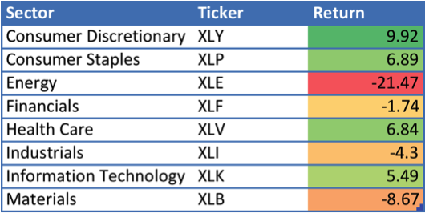

## Sector Winner Performance Distribution

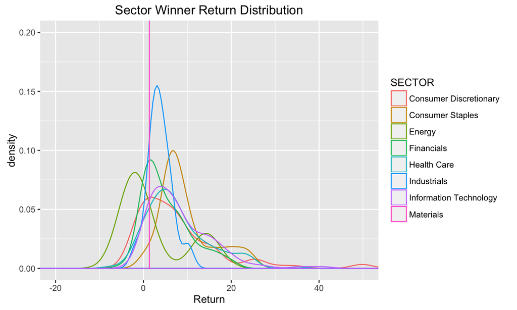

## Top Performing Funds in Consumer Discretionary

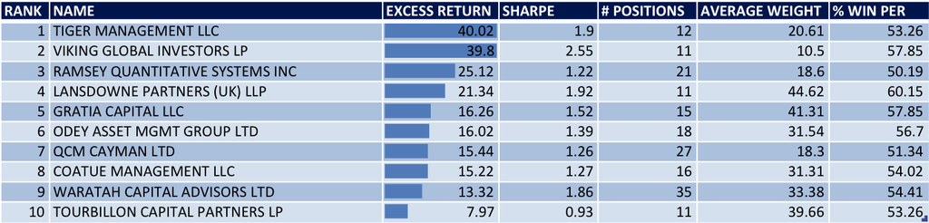

## Top Performing Funds in Consumer Staples

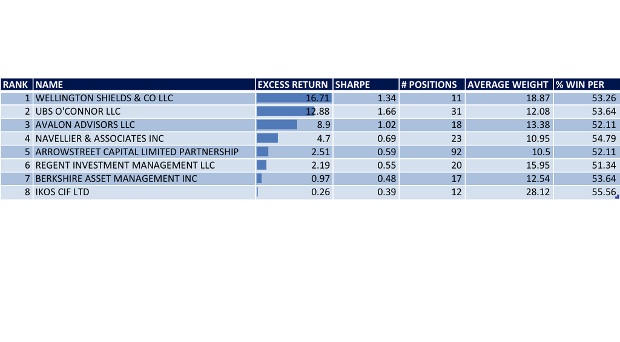

## Top Performing Funds in Energy

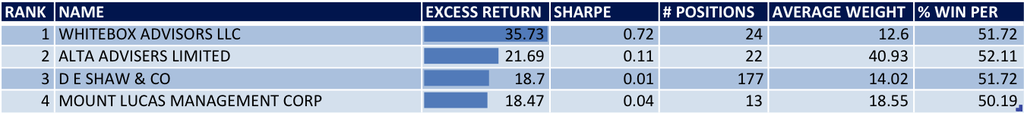

- Funds give avg. return -28.03, and avg. Sharpe -0.56
- Sector benchmark return is -21.47
- Although avg. excess return of top 4 is 23.65, #3 and #4’s absolute sector returns are negative

## Top Performing Funds in Financials

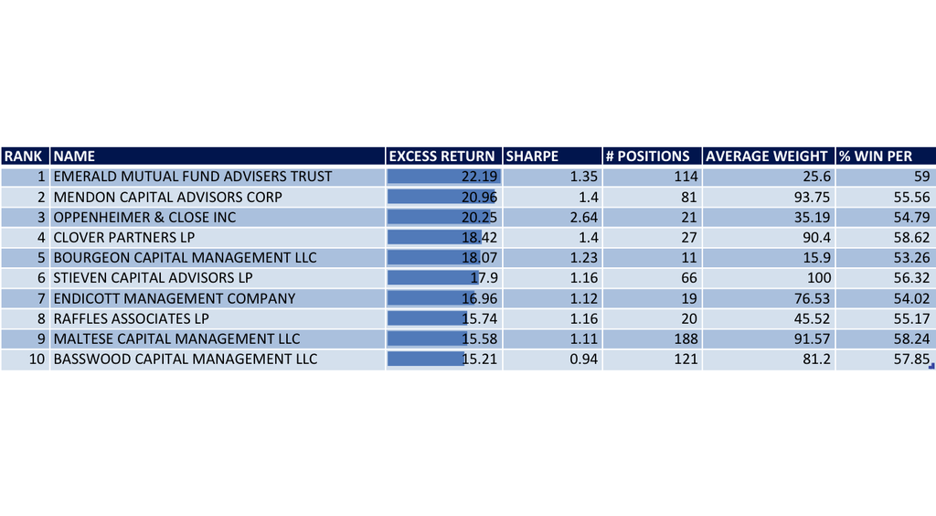

## Top Performing Funds in Health Care

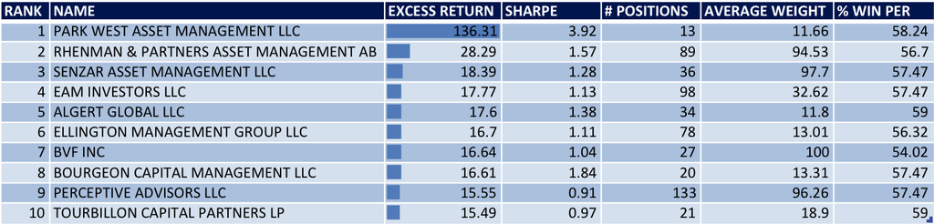

- Although the sector benchmark return 6.84 is relatively high, #1 fund has produced impressive excess return, Sharpe ratio, and % Win

## Top Performing Funds in Industrials

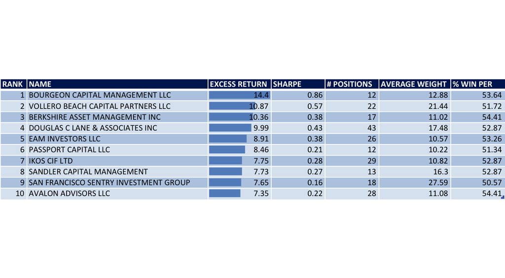

## Top Performing Funds in Information Technology

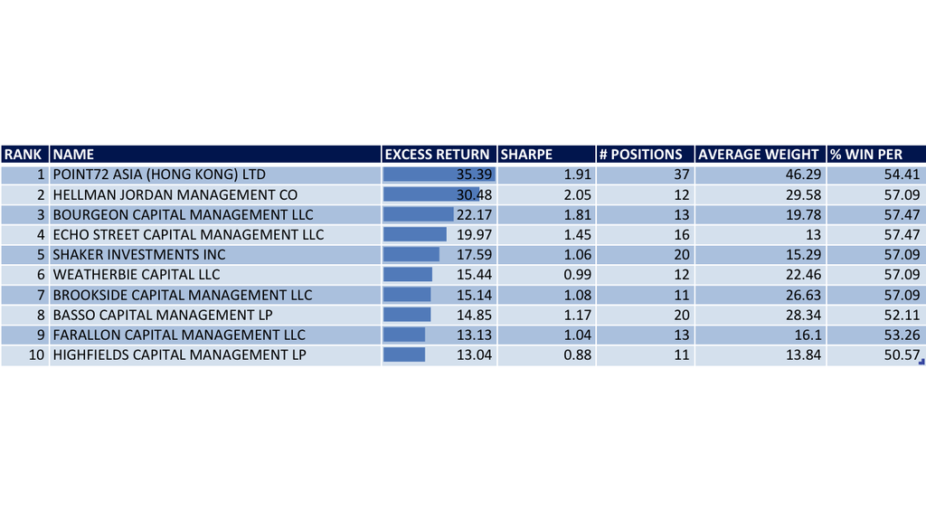

## Top Performing Funds in Materials

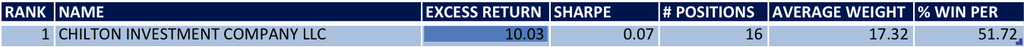

- Funds give avg. return -16.76, and avg. Sharpe -0.35
- Sector benchmark return is -8.67

## Total Fund Performance

## Overall…

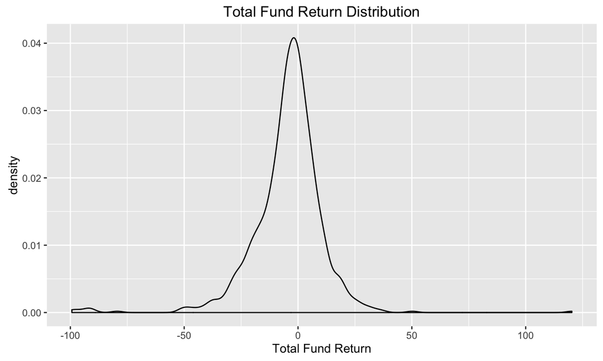

## Future Analysis

- May want to look at the major underlying holdings of funds
- May want to track historial performance of funds
- May want to explore sector performance correlations